# exploration-Copy1

```python
# import all packages and set plots to be embedded inline
import numpy as np
import pandas as pd
import matplotlib.pyplot as plt
import seaborn as sb

%matplotlib inline
```

```python
# my data are load from this 2 dataset
#df2018 = pd.read_csv('201812-fordgobike-tripdata.csv')
#df2019 = pd.read_csv('201912-baywheels-tripdata.csv')
```

### What is the structure of your dataset?

> There are 131363 entries in 2018's data and 150102 in 2019's data. The start and end station name are being recorded per customer for the particular trip. There are only 2 types of user type for the records. The dateTime also being recored per particular trip.

### What is/are the main feature(s) of interest in your dataset?

> I am interested to know which station having higher demand on bike renting and which are the station where the user usually stop at. Also, i would like to know the data by different period of time in a day, i.e. morning, afternoon and evening.

## Univariate Exploration

I'll start by looking at the distribution of the main variable of interest : start stations and the time for the rental start.

repeat the same for 2019's data

```python
# retrieve for from database to fasten the process
dfClean = pd.read_csv('dfClean.csv')
```

```python
# check data
dfClean
```

|  | Unnamed: 0 | start_station_name | StartAt | Year | Count |
| --- | --- | --- | --- | --- | --- |
| 0 | 70 | 21st Ave at International Blvd | Morning | 2018 | 2 |
| 1 | 667 | Oak St at 1st St | Morning | 2018 | 2 |
| 2 | 211 | Almaden Blvd at San Fernando St | Morning | 2018 | 2 |
| 3 | 375 | Farnam St at Fruitvale Ave | Morning | 2018 | 2 |
| 4 | 208 | Almaden Blvd at Balbach St | Morning | 2018 | 2 |
| 5 | 235 | Berry St at 4th St | Morning | 2018 | 902 |
| 6 | 575 | Market St at 10th St | Morning | 2018 | 928 |
| 7 | 763 | San Francisco Ferry Building (Harry Bridges Pl... | Morning | 2018 | 1043 |
| 8 | 754 | San Francisco Caltrain (Townsend St at 4th St) | Morning | 2018 | 1161 |
| 9 | 757 | San Francisco Caltrain Station 2 (Townsend St... | Morning | 2018 | 1743 |
| 10 | 68 | 21st Ave at International Blvd | Afternoon | 2018 | 1 |
| 11 | 373 | Farnam St at Fruitvale Ave | Afternoon | 2018 | 2 |
| 12 | 674 | Palm St at Willow St | Afternoon | 2018 | 2 |
| 13 | 666 | Oak St at 1st St | Afternoon | 2018 | 3 |
| 14 | 74 | 23rd Ave at Foothill Blvd | Afternoon | 2018 | 3 |
| 15 | 639 | Montgomery St BART Station (Market St at 2nd St) | Afternoon | 2018 | 919 |
| 16 | 701 | Powell St BART Station (Market St at 4th St) | Afternoon | 2018 | 994 |
| 17 | 860 | The Embarcadero at Sansome St | Afternoon | 2018 | 1008 |
| 18 | 573 | Market St at 10th St | Afternoon | 2018 | 1027 |
| 19 | 761 | San Francisco Ferry Building (Harry Bridges Pl... | Afternoon | 2018 | 1038 |
| 20 | 652 | Newhall St at 3rd St | Evening | 2018 | 1 |
| 21 | 947 | Willow St at Vine St | Evening | 2018 | 1 |
| 22 | 613 | Mendell St at Fairfax Ave | Evening | 2018 | 1 |
| 23 | 942 | Williams Ave at 3rd St | Evening | 2018 | 1 |
| 24 | 675 | Palm St at Willow St | Evening | 2018 | 1 |
| 25 | 640 | Montgomery St BART Station (Market St at 2nd St) | Evening | 2018 | 478 |
| 26 | 756 | San Francisco Caltrain Station 2 (Townsend St... | Evening | 2018 | 501 |
| 27 | 705 | Powell St BART Station (Market St at 5th St) | Evening | 2018 | 501 |
| 28 | 574 | Market St at 10th St | Evening | 2018 | 593 |
| 29 | 702 | Powell St BART Station (Market St at 4th St) | Evening | 2018 | 662 |
| 30 | 85 | 1st St at Younger Ave | Morning | 2019 | 1 |
| 31 | 899 | Parkmoor Ave at Race St | Morning | 2019 | 1 |
| 32 | 486 | Evans Ave at Mendell St | Morning | 2019 | 1 |
| 33 | 715 | Kerley Dr at Rosemary St | Morning | 2019 | 1 |
| 34 | 408 | Columbia Ave at Bird Ave | Morning | 2019 | 1 |
| 35 | 301 | Berry St at 4th St | Morning | 2019 | 798 |
| 36 | 1082 | Steuart St at Market St | Morning | 2019 | 842 |
| 37 | 652 | Howard St at Beale St | Morning | 2019 | 968 |
| 38 | 760 | Market St at 10th St | Morning | 2019 | 1005 |
| 39 | 995 | San Francisco Caltrain (Townsend St at 4th St) | Morning | 2019 | 2034 |
| 40 | 805 | Mercado Way at Sierra Rd | Afternoon | 2019 | 1 |
| 41 | 57 | 17th St at Santa Clara St | Afternoon | 2019 | 1 |
| 42 | 202 | 5th St at Taylor St | Afternoon | 2019 | 1 |
| 43 | 689 | Jackson St at N 1st St | Afternoon | 2019 | 1 |
| 44 | 72 | 19th St at William St | Afternoon | 2019 | 2 |
| 45 | 175 | 4th St at 16th St | Afternoon | 2019 | 694 |
| 46 | 924 | Powell St BART Station (Market St at 4th St) | Afternoon | 2019 | 694 |
| 47 | 831 | Montgomery St BART Station (Market St at 2nd St) | Afternoon | 2019 | 707 |
| 48 | 758 | Market St at 10th St | Afternoon | 2019 | 884 |
| 49 | 299 | Berry St at 4th St | Afternoon | 2019 | 1040 |
| 50 | 530 | Foothill Blvd at Harrington Ave | Evening | 2019 | 1 |
| 51 | 886 | Park Ave at Laurel Grove Ln | Evening | 2019 | 1 |
| 52 | 889 | Park Ave at Race St | Evening | 2019 | 1 |
| 53 | 263 | Asbury St at The Alameda | Evening | 2019 | 1 |
| 54 | 868 | Oak St at 1st St | Evening | 2019 | 1 |
| 55 | 928 | Powell St BART Station (Market St at 5th St) | Evening | 2019 | 405 |
| 56 | 925 | Powell St BART Station (Market St at 4th St) | Evening | 2019 | 461 |
| 57 | 300 | Berry St at 4th St | Evening | 2019 | 461 |
| 58 | 759 | Market St at 10th St | Evening | 2019 | 513 |
| 59 | 994 | San Francisco Caltrain (Townsend St at 4th St) | Evening | 2019 | 523 |

```python
dfGrouped = dfClean.groupby(['start_station_name','StartAt'], as_index=False)['Count'].sum().sort_values(['Count'])
dfGrouped
```

|  | start_station_name | StartAt | Count |
| --- | --- | --- | --- |
| 0 | 17th St at Santa Clara St | Afternoon | 1 |
| 37 | Parkmoor Ave at Race St | Morning | 1 |
| 36 | Park Ave at Race St | Evening | 1 |
| 35 | Park Ave at Laurel Grove Ln | Evening | 1 |
| 34 | Palm St at Willow St | Evening | 1 |
| 31 | Oak St at 1st St | Evening | 1 |
| 29 | Newhall St at 3rd St | Evening | 1 |
| 26 | Mercado Way at Sierra Rd | Afternoon | 1 |
| 49 | Williams Ave at 3rd St | Evening | 1 |
| 21 | Kerley Dr at Rosemary St | Morning | 1 |
| 20 | Jackson St at N 1st St | Afternoon | 1 |
| 18 | Foothill Blvd at Harrington Ave | Evening | 1 |
| 15 | Evans Ave at Mendell St | Morning | 1 |
| 14 | Columbia Ave at Bird Ave | Morning | 1 |
| 25 | Mendell St at Fairfax Ave | Evening | 1 |
| 50 | Willow St at Vine St | Evening | 1 |
| 2 | 1st St at Younger Ave | Morning | 1 |
| 3 | 21st Ave at International Blvd | Afternoon | 1 |
| 10 | Asbury St at The Alameda | Evening | 1 |
| 7 | 5th St at Taylor St | Afternoon | 1 |
| 1 | 19th St at William St | Afternoon | 2 |
| 4 | 21st Ave at International Blvd | Morning | 2 |
| 33 | Palm St at Willow St | Afternoon | 2 |
| 8 | Almaden Blvd at Balbach St | Morning | 2 |
| 32 | Oak St at 1st St | Morning | 2 |
| 16 | Farnam St at Fruitvale Ave | Afternoon | 2 |
| 17 | Farnam St at Fruitvale Ave | Morning | 2 |
| 9 | Almaden Blvd at San Fernando St | Morning | 2 |
| 5 | 23rd Ave at Foothill Blvd | Afternoon | 3 |
| 30 | Oak St at 1st St | Afternoon | 3 |
| 12 | Berry St at 4th St | Evening | 461 |
| 28 | Montgomery St BART Station (Market St at 2nd St) | Evening | 478 |
| 43 | San Francisco Caltrain Station 2 (Townsend St... | Evening | 501 |
| 41 | San Francisco Caltrain (Townsend St at 4th St) | Evening | 523 |
| 6 | 4th St at 16th St | Afternoon | 694 |
| 47 | Steuart St at Market St | Morning | 842 |
| 40 | Powell St BART Station (Market St at 5th St) | Evening | 906 |
| 19 | Howard St at Beale St | Morning | 968 |
| 48 | The Embarcadero at Sansome St | Afternoon | 1008 |
| 45 | San Francisco Ferry Building (Harry Bridges Pl... | Afternoon | 1038 |
| 11 | Berry St at 4th St | Afternoon | 1040 |
| 46 | San Francisco Ferry Building (Harry Bridges Pl... | Morning | 1043 |
| 23 | Market St at 10th St | Evening | 1106 |
| 39 | Powell St BART Station (Market St at 4th St) | Evening | 1123 |
| 27 | Montgomery St BART Station (Market St at 2nd St) | Afternoon | 1626 |
| 38 | Powell St BART Station (Market St at 4th St) | Afternoon | 1688 |
| 13 | Berry St at 4th St | Morning | 1700 |
| 44 | San Francisco Caltrain Station 2 (Townsend St... | Morning | 1743 |
| 22 | Market St at 10th St | Afternoon | 1911 |
| 24 | Market St at 10th St | Morning | 1933 |
| 42 | San Francisco Caltrain (Townsend St at 4th St) | Morning | 3195 |

```python
# Let's group by the stations name to produce a table to ease the reading
dfGrouped.sort_values(['Count','start_station_name'])
```

|  | start_station_name | StartAt | Count |
| --- | --- | --- | --- |
| 0 | 17th St at Santa Clara St | Afternoon | 1 |
| 2 | 1st St at Younger Ave | Morning | 1 |
| 3 | 21st Ave at International Blvd | Afternoon | 1 |
| 7 | 5th St at Taylor St | Afternoon | 1 |
| 10 | Asbury St at The Alameda | Evening | 1 |
| 14 | Columbia Ave at Bird Ave | Morning | 1 |
| 15 | Evans Ave at Mendell St | Morning | 1 |
| 18 | Foothill Blvd at Harrington Ave | Evening | 1 |
| 20 | Jackson St at N 1st St | Afternoon | 1 |
| 21 | Kerley Dr at Rosemary St | Morning | 1 |
| 25 | Mendell St at Fairfax Ave | Evening | 1 |
| 26 | Mercado Way at Sierra Rd | Afternoon | 1 |
| 29 | Newhall St at 3rd St | Evening | 1 |
| 31 | Oak St at 1st St | Evening | 1 |
| 34 | Palm St at Willow St | Evening | 1 |
| 35 | Park Ave at Laurel Grove Ln | Evening | 1 |
| 36 | Park Ave at Race St | Evening | 1 |
| 37 | Parkmoor Ave at Race St | Morning | 1 |
| 49 | Williams Ave at 3rd St | Evening | 1 |
| 50 | Willow St at Vine St | Evening | 1 |
| 1 | 19th St at William St | Afternoon | 2 |
| 4 | 21st Ave at International Blvd | Morning | 2 |
| 8 | Almaden Blvd at Balbach St | Morning | 2 |
| 9 | Almaden Blvd at San Fernando St | Morning | 2 |
| 16 | Farnam St at Fruitvale Ave | Afternoon | 2 |
| 17 | Farnam St at Fruitvale Ave | Morning | 2 |
| 32 | Oak St at 1st St | Morning | 2 |
| 33 | Palm St at Willow St | Afternoon | 2 |
| 5 | 23rd Ave at Foothill Blvd | Afternoon | 3 |
| 30 | Oak St at 1st St | Afternoon | 3 |
| 12 | Berry St at 4th St | Evening | 461 |
| 28 | Montgomery St BART Station (Market St at 2nd St) | Evening | 478 |
| 43 | San Francisco Caltrain Station 2 (Townsend St... | Evening | 501 |
| 41 | San Francisco Caltrain (Townsend St at 4th St) | Evening | 523 |
| 6 | 4th St at 16th St | Afternoon | 694 |
| 47 | Steuart St at Market St | Morning | 842 |
| 40 | Powell St BART Station (Market St at 5th St) | Evening | 906 |
| 19 | Howard St at Beale St | Morning | 968 |
| 48 | The Embarcadero at Sansome St | Afternoon | 1008 |
| 45 | San Francisco Ferry Building (Harry Bridges Pl... | Afternoon | 1038 |
| 11 | Berry St at 4th St | Afternoon | 1040 |
| 46 | San Francisco Ferry Building (Harry Bridges Pl... | Morning | 1043 |
| 23 | Market St at 10th St | Evening | 1106 |
| 39 | Powell St BART Station (Market St at 4th St) | Evening | 1123 |
| 27 | Montgomery St BART Station (Market St at 2nd St) | Afternoon | 1626 |
| 38 | Powell St BART Station (Market St at 4th St) | Afternoon | 1688 |
| 13 | Berry St at 4th St | Morning | 1700 |
| 44 | San Francisco Caltrain Station 2 (Townsend St... | Morning | 1743 |
| 22 | Market St at 10th St | Afternoon | 1911 |
| 24 | Market St at 10th St | Morning | 1933 |
| 42 | San Francisco Caltrain (Townsend St at 4th St) | Morning | 3195 |

[figure not shown]

```python
cat1_order = dfClean.sort_values('Count')['start_station_name'].unique()
cat2_order = ['Morning','Afternoon','Evening']

artists = [] # for storing references to plot elements
baselines = np.zeros(len(cat1_order))
cat1_counts = dfClean.groupby('start_station_name')['Count'].sum()

#dfClean.groupby('start_station_name', as_index=False).agg({"Count": "sum"})

# for each second-variable category:
for i in range(len(cat2_order)):
    # isolate the counts of the first category,
    cat2 = cat2_order[i]
    inner_counts = dfClean[dfClean['StartAt'] == cat2]['Count']
    inner_props = inner_counts / cat1_counts[1]
    # then plot those counts on top of the accumulated baseline
    bars = plt.bar(x = np.arange(len(cat1_order)),
                   height = inner_props[cat1_order],
                   bottom = baselines)
    artists.append(bars)
    baselines += inner_props[cat1_order]

plt.xticks(np.arange(len(cat1_order)), cat1_order, rotation = 90)
plt.legend(reversed(artists), reversed(cat2_order), framealpha = 1,
           bbox_to_anchor = (1, 0.5), loc = 6);
```

[output not shown]

[figure not shown]

```python
cat1_order = [2018, 2019]
cat2_order = ['Morning','Afternoon','Evening']

plt.figure(figsize = [52, 5])

# stacked bar chart, absolute counts
plt.subplot(1, 2, 1)

baselines = np.zeros(len(cat1_order))

# for each second-variable category:
for i in range(len(cat2_order)):
    # isolate the counts of the first category,
    cat1 = cat1_order[i]
    cat2 = cat2_order[i]
    inner_counts = dfClean[(dfClean['StartAt'] == cat2) & (dfClean['Year'] == cat1)]['Count']
    # then plot those counts on top of the accumulated baseline
    plt.bar(x = np.arange(len(cat1_order)), height = inner_counts[cat1_order], bottom = baselines)
    baselines += inner_counts[cat1_order]

plt.xticks(np.arange(len(cat1_order)), cat1_order, rotation = 90)
plt.legend(cat2_order)
```

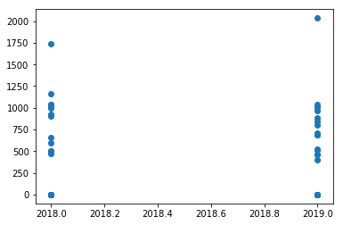

```python
df = pd.DataFrame(dfClean, columns=['Year','Count'])
order = [2018, 2019]
df['Year'] = pd.Categorical(df['Year'], order)
df.sort_values(by=['Year'], inplace=True)
plt.scatter(df['Year'], df['Count'])
```

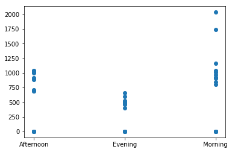

```python
df = pd.DataFrame(dfClean, columns=['StartAt','Count'])
order = ['Morning', 'Afternoon', 'Evening']
df['StartAt'] = pd.Categorical(df['StartAt'], order)
df.sort_values(by=['StartAt'], inplace=True)
plt.scatter(df['StartAt'], df['Count'])
```

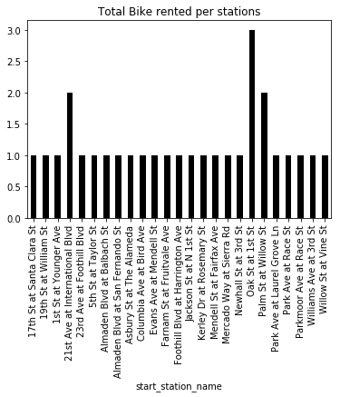

```python
dfClean[dfClean['Count']< 10].groupby('start_station_name')['Count'].nunique().plot(kind='bar', color = 'Black', title ='Total Bike rented per stations')
```

I am trying to set the size of the bin, because currently it is showing 1.0,1.5 and etc just like the aboved graph

[output not shown]

[output cut: 28 more lines]

[output not shown]

[figure not shown]

```python
dfClean[dfClean['Count']< 10].groupby('start_station_name')['Count'].nunique().plot(kind='bar', color = 'Black', bin=[1,2,3])
```

This is obviously not correct because the data should be more than 100

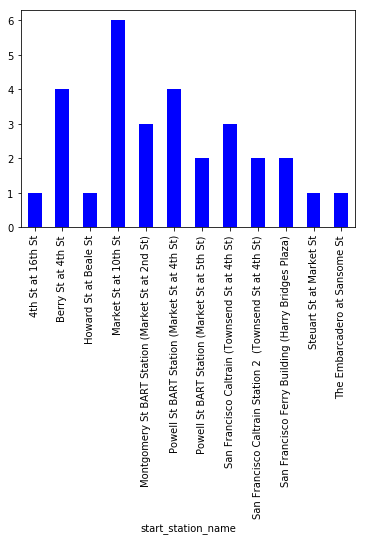

```python
dfClean[dfClean['Count']> 10].groupby('start_station_name')['Count'].nunique().plot(kind='bar', color = 'Blue')
```